# Introduction to bayesplot (mcmc_ series)

## NUTS診断系

以下は、HMCの細かい設定に関する出力や対数事後確率を出力したいときの関数になります。  
出力が長いものは、head()で出力数を制限しています。

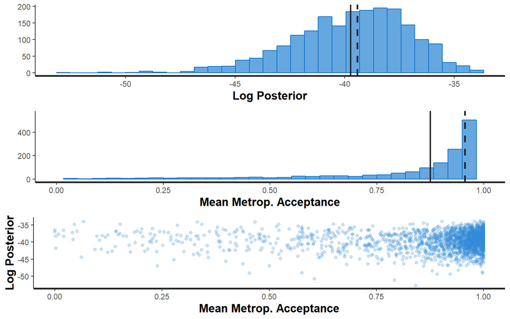

```r
## デフォルト
stan_diag(fit)
```

```r
## beyasplot

## nuts関連の値
nuts_params(fit) %>% head()
```

```
  Iteration     Parameter     Value Chain
1         1 accept_stat__ 0.9915962     1
2         2 accept_stat__ 0.9542163     1
3         3 accept_stat__ 0.9619325     1
4         4 accept_stat__ 0.9974984     1
5         5 accept_stat__ 0.9948058     1
6         6 accept_stat__ 0.6023858     1
```

```r
## 対数事後確率
log_posterior(fit) %>% head()
```

```
  Iteration     Value Chain
1         1 -41.82965     1
2         2 -36.26125     1
3         3 -40.15663     1
4         4 -38.28819     1
5         5 -37.64542     1
6         6 -40.68307     1
```

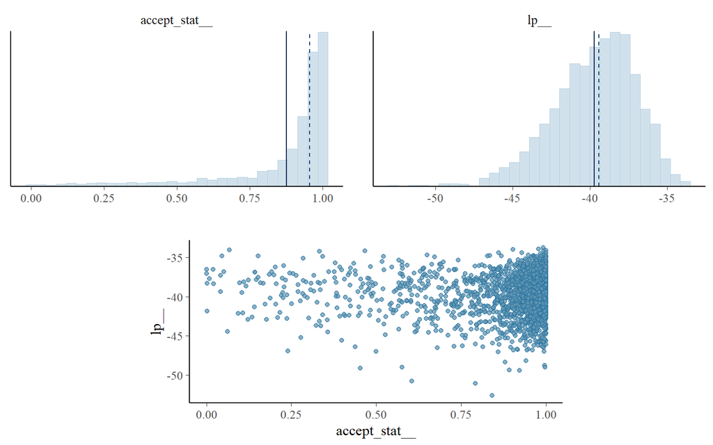

```r
## 上記を図で出力
mcmc_nuts_acceptance(nuts_params(fit), log_posterior(fit))
```

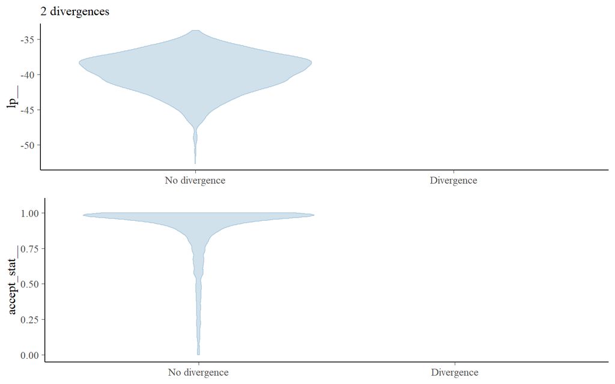

```r
mcmc_nuts_divergence(nuts_params(fit), log_posterior(fit))
```

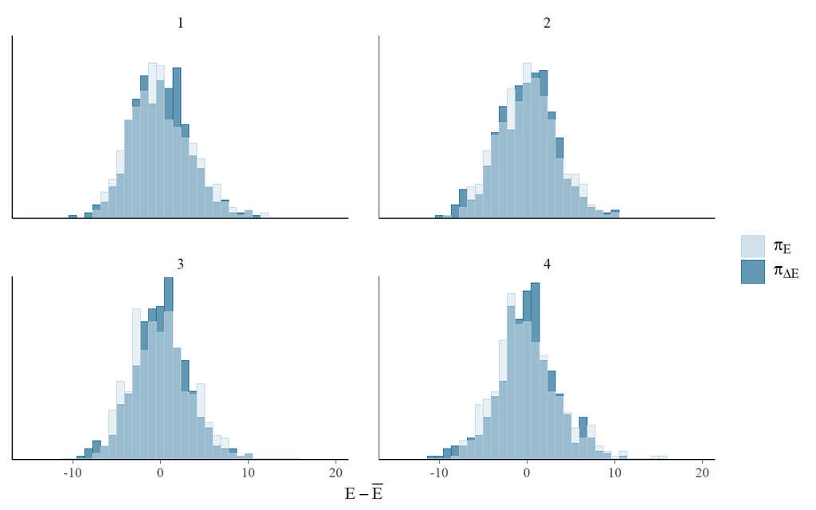

```r
mcmc_nuts_energy(nuts_params(fit))
```

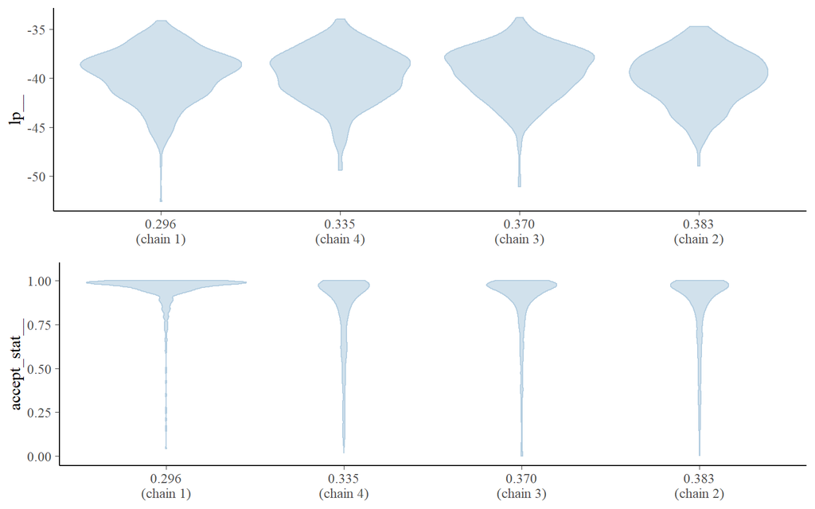

```r
mcmc_nuts_stepsize(nuts_params(fit), log_posterior(fit))
```

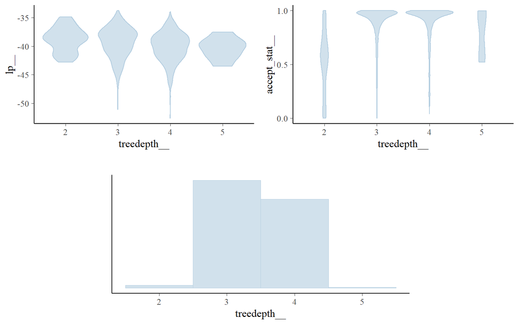

```r
mcmc_nuts_treedepth(nuts_params(fit), log_posterior(fit))
```

## 並行でだす関数(mcmc_parcoord)

複数のパラメータを同時に(並行に)出力する関数です。  
条件間・参加者間を通して確認したいときに便利かもしれません。  
ただ、出力が結構重いので注意が必要です。

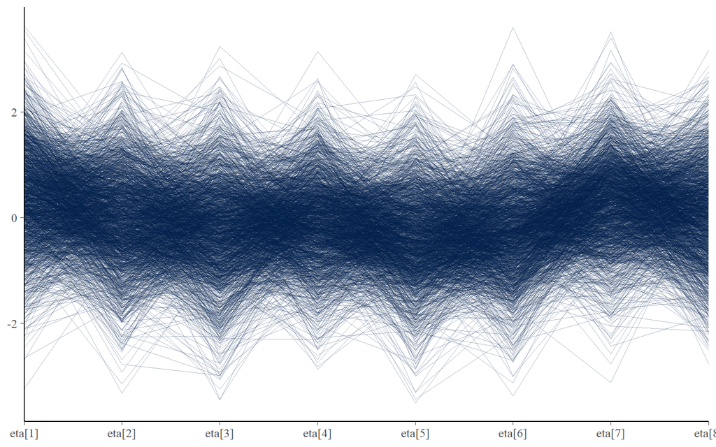

```r
## bayesplot
mcmc_parcoord(samples, regex_pars = "^eta")
```

```r
mcmc_parcoord_data(samples, regex_pars = "^eta") %>% head
```

```
# A tibble: 6 x 4
   Draw Parameter    Value Divergent
  <int> <fct>        <dbl>     <dbl>
1     1 eta[1]    -0.0968          0
2     2 eta[1]     0.736           0
3     3 eta[1]     1.25            0
4     4 eta[1]     1.30            0
5     5 eta[1]    -0.00446         0
6     6 eta[1]    -0.202           0
```

## パラメータリカバリ

モデルの確認のためにパラメータリカバリの性能を確かめることは多々あるとは思いますが、真値と推定値の確認に便利な関数が以下になります。

```r
## 真値データの作成(8shcool.stan用)

J <- 10

set.seed(1234)
eta <- rnorm(J, 0, 1)
mu <- 7.5  ## 適当です
tau <- 6.3  ## 適当です
sigma <- abs(rnorm(J, 0, 1))
theta <- NULL
y <- NULL
for (j in 1:J) {
    theta[j] <- mu + tau * eta[j]
    y[j] <- rnorm(1, theta[j], sigma[j])
}
true <- c(mu, tau, eta, theta)

## Stan data 指定
schools_dat <- list(J = J, y = y, sigma = sigma)

## stan を回す(Modelを読み込んでいる前提です。)
fit <- sampling(object = model, data = schools_dat, iter = 1000, chains = 4)

## 結果 ##
fit
```

```
Inference for Stan model: 4a38cae9bad394789360bce03f17c3ed.
4 chains, each with iter=1000; warmup=500; thin=1;
post-warmup draws per chain=500, total post-warmup draws=2000.

            mean se_mean   sd   2.5%    25%    50%    75%  97.5% n_eff
mu          4.90    0.17 2.71  -0.39   3.30   4.84   6.43  10.13   250
tau         7.46    0.14 2.22   4.53   5.86   6.96   8.53  13.32   244
eta[1]     -0.70    0.02 0.38  -1.43  -0.95  -0.71  -0.45   0.06   329
eta[2]      0.55    0.02 0.40  -0.21   0.29   0.55   0.82   1.35   306
eta[3]      1.30    0.03 0.51   0.34   0.96   1.29   1.62   2.33   272
eta[4]     -1.75    0.03 0.55  -2.84  -2.12  -1.75  -1.38  -0.65   301
eta[5]      0.66    0.02 0.41  -0.13   0.39   0.65   0.93   1.49   299
eta[6]      0.82    0.03 0.42   0.04   0.54   0.82   1.10   1.67   271
eta[7]     -0.10    0.02 0.35  -0.78  -0.33  -0.10   0.14   0.61   313
eta[8]     -0.25    0.02 0.36  -0.97  -0.48  -0.25  -0.01   0.46   359
eta[9]     -0.13    0.02 0.35  -0.82  -0.37  -0.13   0.09   0.57   323
eta[10]    -0.65    0.02 0.46  -1.58  -0.96  -0.65  -0.34   0.25   487
theta[1]   -0.01    0.01 0.49  -0.94  -0.32  -0.01   0.32   0.95  2289
theta[2]    8.68    0.02 1.00   6.71   8.01   8.69   9.34  10.59  2247
theta[3]   13.87    0.01 0.79  12.33  13.34  13.87  14.39  15.45  3180
theta[4]   -7.25    0.00 0.07  -7.37  -7.29  -7.25  -7.20  -7.12  1910
theta[5]    9.44    0.02 0.93   7.62   8.80   9.44  10.09  11.25  2310
theta[6]   10.53    0.00 0.11  10.31  10.45  10.52  10.60  10.76  1787
theta[7]    4.17    0.01 0.52   3.19   3.83   4.16   4.52   5.20  2159
theta[8]    3.14    0.02 0.91   1.37   2.52   3.13   3.74   4.86  2065
theta[9]    3.94    0.02 0.82   2.27   3.39   3.92   4.46   5.54  2074
theta[10]   0.30    0.07 2.32  -4.02  -1.29   0.27   1.83   5.28   968
lp__      -19.94    0.18 3.30 -26.80 -22.05 -19.72 -17.41 -14.41   328
          Rhat
mu        1.01
tau       1.01
eta[1]    1.01
eta[2]    1.01
eta[3]    1.01
eta[4]    1.01
eta[5]    1.01
eta[6]    1.01
eta[7]    1.01
eta[8]    1.01
eta[9]    1.01
eta[10]   1.01
theta[1]  1.00
theta[2]  1.00
theta[3]  1.00
theta[4]  1.00
theta[5]  1.00
theta[6]  1.00
theta[7]  1.00
theta[8]  1.00
theta[9]  1.00
theta[10] 1.00
lp__      1.00

Samples were drawn using NUTS(diag_e) at Sat Dec 01 12:43:12 2018.
For each parameter, n_eff is a crude measure of effective sample size,
and Rhat is the potential scale reduction factor on split chains (at
convergence, Rhat=1).
```

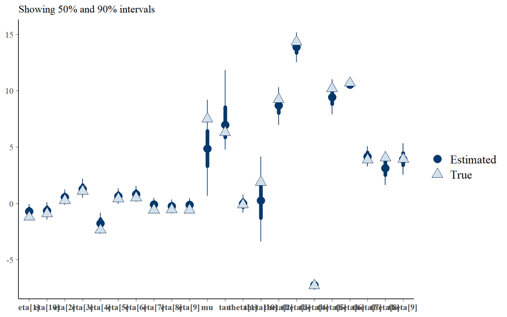

```r
## true(真値)との比較
matfit <- as.matrix(fit)

## 推定値と真値の比較
mcmc_recover_intervals(matfit[, -ncol(matfit)], true)  ## fitの最後にでてくる'lp__'の分を抜いている
```

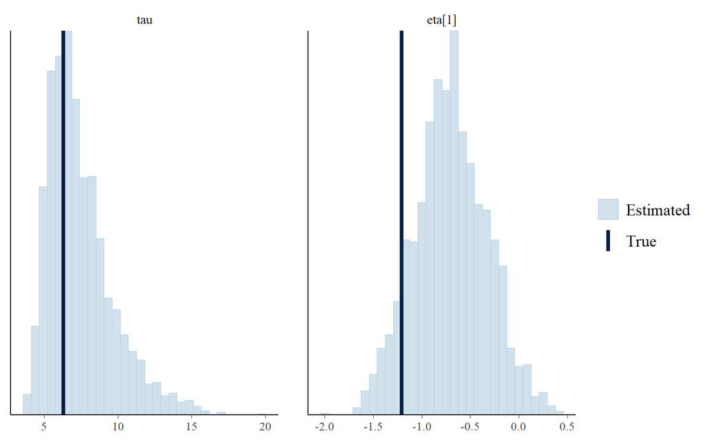

```r
## ヒストグラム(vs 真値)
mcmc_recover_hist(matfit[, 2:3], true[2:3])
```

```r
## 散布図(vs 真値) だとおもうのですがこれだけうまくいきません。

# mcmc_recover_scatter(matfit[,-ncol(matfit)], true,point_est = 'mean')
```

真値と簡単に比較できるのは、便利ですね。  
ただ、trueの入れる順序を間違うと誤った解釈につながる可能性ありますし、そこら辺注意ですね・・・。

# 関数を探したいときに便利な関数

これだけ多くのmcmc_関数があるととても便利な反面、いざ使うと気になると思い出せないですよね。  
かといって、暗記するのも大変だし…

そんなときに便利なのが、関数を探すための関数があります。

```r
## bayesplot
available_mcmc()  ## mcmc_関数の種類を提示
```

```
bayesplot MCMC module:
  mcmc_acf
  mcmc_acf_bar
  mcmc_areas
  mcmc_areas_data
  mcmc_areas_ridges
  mcmc_areas_ridges_data
  mcmc_combo
  mcmc_dens
  mcmc_dens_chains
  mcmc_dens_chains_data
  mcmc_dens_overlay
  mcmc_hex
  mcmc_hist
  mcmc_hist_by_chain
  mcmc_intervals
  mcmc_intervals_data
  mcmc_neff
  mcmc_neff_data
  mcmc_neff_hist
  mcmc_nuts_acceptance
  mcmc_nuts_divergence
  mcmc_nuts_energy
  mcmc_nuts_stepsize
  mcmc_nuts_treedepth
  mcmc_pairs
  mcmc_parcoord
  mcmc_parcoord_data
  mcmc_recover_hist
  mcmc_recover_intervals
  mcmc_recover_scatter
  mcmc_rhat
  mcmc_rhat_data
  mcmc_rhat_hist
  mcmc_scatter
  mcmc_trace
  mcmc_trace_highlight
  mcmc_violin
```

```r
## 特定の用途に関する関数を探したい(ここでは、rhatもしくはn_eff関連の関数を検索)。
available_mcmc("rhat|neff")
```

```
bayesplot MCMC module:
(matching pattern 'rhat|neff')
  mcmc_neff
  mcmc_neff_data
  mcmc_neff_hist
  mcmc_rhat
  mcmc_rhat_data
  mcmc_rhat_hist
```

# とりあえずこのパッケージで遊びたい

そんな方のために、デモデータおよびデモ事後乱数も付いています。  
こちらも参考まで

```r
## example_ シリーズ

example_mcmc_draws() %>% head()
```

```
[1] -14.147624 -20.037724 -20.982792 -36.288584  -7.581124 -10.409814
```

```r
example_group_data() %>% head()
```

```
[1] GroupB GroupB GroupB GroupB GroupB GroupA
Levels: GroupA GroupB
```

```r
example_x_data() %>% head()
```

```
[1] 121.11753  89.36188 115.44316  99.44964  92.74571 107.90184
```

```r
example_y_data() %>% head()
```

```
[1]  65  98  85  83 115  98
```

```r
# example_yrep_draws() %>% head() ##
# 表示数が多いのでコメントアウトしています。
```

ここらへんを使えば、ppc_シリーズの挙動も簡単に調べられると思います。  
ただし、ppc_シリーズは、少しクセが強かったり、パラメータ数増やすと結構見にくかったりで大変なので頑張ってくださいｗ

# まとめ

こんなかんじでbayesplotの特にmcmc_シリーズを見てきました。  
便利な部分と既存の関数が良い部分と様々でした。

自分の用途や余裕に合わせて使いこなせたらいいですね。Enjoy!!

関連サイト: [公式](http://mc-stan.org/bayesplot/articles/index.html)

# 今回使用した全Rコード

```r
# setwd('')

rm(list = ls())
library(tidyverse)  ## ほぼパイプのために読み込んでいます。
library(rstan)
library(bayesplot)  ## こいつが今回の主役です。
rstan_options(auto_write = TRUE)  ## なくても構いません
options(mc.cores = parallel::detectCores())  ## なくても構いません
options(max.print = 99999)  ## なくても構いません

schools_dat <- list(J = 8, y = c(28, 8, -3, 7, -1, 1, 18, 12), sigma = c(15,
    10, 16, 11, 9, 11, 10, 18))

model <- stan_model("model.stan")

fit <- sampling(object = model, data = schools_dat, iter = 1000, chains = 4)

## 結果 ##
fit

## デフォルト not bayesplot
stan_rhat(fit)
stan_rhat(fit)$data  ## dataとしてとってきたい

## bayesplot

## rhatがdataとして出力される
rhat(fit)

## rhatが図として出力
mcmc_rhat(rhat(fit))

## 表示した図に関するdata
mcmc_rhat_data(rhat(fit))

## histgramとして表示(stan_rhatに近い形で出力)
mcmc_rhat_hist(rhat(fit))

## 特定のパラメータのR hat をみたい。
stan_rhat(fit, pars = c("mu", "eta"))  ## stanの関数
mcmc_rhat(rhat(fit, pars = c("mu", "eta")))  ## bayesplotの関数

## デフォルト
stan_trace(fit, inc_warmup = T)  ## inc_warmupでwarmup区間指定可能
traceplot(fit, inc_warmup = T)

## bayesplot
samples <- as.array(fit)
mcmc_trace(samples, pars = "mu")  ## n_warmupでwarmup区間指定可能

## 特定のchainを特に見たい(目立たせて確認したい)
mcmc_trace_highlight(samples, pars = "mu", highlight = 2)

## 事後分布と同時に確認したい(パラメータ多いと重いので指定推奨)
mcmc_combo(samples, pars = c("mu"))

## デフォルト
stan_ac(fit, pars = c("mu", "tau"))

## chain別
stan_ac(fit, pars = c("mu", "tau"), separate_chains = T)

## bayesplot

## 折れ線表記
mcmc_acf(samples, pars = c("mu", "tau"))

## 棒グラフ表記
mcmc_acf_bar(samples, pars = c("mu", "tau"))

## デフォルト
stan_ess(fit)
stan_ess(fit)$data  ## dataとして出力

## bayesplot n_effの値をdataとして確認
neff_ratio(fit)

## 図で確認
mcmc_neff(neff_ratio(fit))
mcmc_neff_data(neff_ratio(fit))  ## 図で出力したdataを出力
mcmc_neff_hist(neff_ratio(fit))  ## stan_ess()形式で出力

## デフォルト
stan_dens(fit, pars = c("mu", "tau"))
stan_dens(fit, pars = c("mu", "tau"), separate_chains = T)
# stan_dens(fit,pars=c('mu','tau'))$data

## beyasplot
mcmc_dens(samples, pars = c("mu", "tau"))

## chainごとに出力(ただ、一度に出す)
mcmc_dens_chains(samples, pars = c("mu", "tau"))
mcmc_dens_chains_data(samples, pars = c("mu", "tau"))  ## 上図のdataを取ってきたい場合

## stan_dens(separate_chains=T)と同じようなこと実行
mcmc_dens_overlay(samples, pars = c("mu", "tau"))

## デフォルト
stan_plot(fit, pars = "eta", ci_level = 0.95, outer_level = 1, show_density = T,
    point_est = "mean")

## beyasplot
mcmc_areas(samples, regex_pars = "^eta\\[", prob = 0.95, prob_outer = 1, point_est = "mean")
mcmc_areas_data(samples, regex_pars = "^eta\\[", prob = 0.95, prob_outer = 1,
    point_est = "mean")

## それぞれの事前分布が重なって表示されるようにする
## 図がコンパクトになるのが利点(公式)
mcmc_areas_ridges(samples, regex_pars = "^eta\\[", prob = 0.95, prob_outer = 1)
mcmc_areas_ridges_data(samples, regex_pars = "^eta\\[", prob = 0.95, prob_outer = 1)

## 区間だけ図示したい
mcmc_intervals(samples, regex_pars = "^eta\\[", prob = 0.95, prob_outer = 1,
    point_est = "mean")
mcmc_intervals_data(samples, regex_pars = "^eta\\[", prob = 0.95, prob_outer = 1,
    point_est = "mean")

## デフォルト
stan_hist(fit, pars = c("mu", "tau"))

## beyasplot
mcmc_hist(samples, pars = c("mu", "tau"))
mcmc_hist_by_chain(samples, pars = c("mu", "tau"))  ## chain毎

## violin plot
mcmc_violin(samples, pars = "mu")

## 散布図
mcmc_scatter(samples, pars = c("eta[1]", "eta[2]"))

## ヒストグラム(density)と散布図同時に
mcmc_pairs(samples, pars = c("mu", "tau"), diag_fun = c("hist"))  ## 'hist' → 'dens'で変更可能

## デフォルト
stan_diag(fit)

## beyasplot

## nuts関連の値
nuts_params(fit) %>% head()

## 対数事後確率
log_posterior(fit) %>% head()

## 上記を図で出力
mcmc_nuts_acceptance(nuts_params(fit), log_posterior(fit))
mcmc_nuts_divergence(nuts_params(fit), log_posterior(fit))
mcmc_nuts_energy(nuts_params(fit))
mcmc_nuts_stepsize(nuts_params(fit), log_posterior(fit))
mcmc_nuts_treedepth(nuts_params(fit), log_posterior(fit))

## bayesplot
mcmc_parcoord(samples, regex_pars = "^eta")
mcmc_parcoord_data(samples, regex_pars = "^eta") %>% head

## 真値データの作成(8shcool.stan用)

J <- 10

set.seed(1234)
eta <- rnorm(J, 0, 1)
mu <- 7.5  ## 適当です
tau <- 6.3  ## 適当です
sigma <- abs(rnorm(J, 0, 1))
theta <- NULL
y <- NULL
for (j in 1:J) {
    theta[j] <- mu + tau * eta[j]
    y[j] <- rnorm(1, theta[j], sigma[j])
}
true <- c(mu, tau, eta, theta)

## Stan data 指定
schools_dat <- list(J = J, y = y, sigma = sigma)

## stan を回す(Modelを読み込んでいる前提です。)
fit <- sampling(object = model, data = schools_dat, iter = 1000, chains = 4)

## 結果 ##
fit

## true(真値)との比較
matfit <- as.matrix(fit)

## 推定値と真値の比較
mcmc_recover_intervals(matfit[, -ncol(matfit)], true)  ## fitの最後にでてくる'lp__'の分を抜いている

## ヒストグラム(vs 真値)
mcmc_recover_hist(matfit[, 2:3], true[2:3])

## 散布図(vs 真値) だとおもうのですがこれだけうまくいきません。

# mcmc_recover_scatter(matfit[,-ncol(matfit)], true,point_est = 'mean')

## bayesplot
available_mcmc()  ## mcmc_関数の種類を提示

## 特定の用途に関する関数を探したい(ここでは、rhatもしくはn_eff関連の関数を検索)。
available_mcmc("rhat|neff")

## example_ シリーズ
example_mcmc_draws() %>% head()
example_group_data() %>% head()
example_x_data() %>% head()
example_y_data() %>% head()
example_yrep_draws() %>% head()
```

Daiki Hojo

2018-12-01